# Progetto Informatica Umanistica

10/10/2023

## Parte 1

- Con la crescita del PIL mondiale, sono cresciuti anche gli incassi dell’industria cinematografica?
- L’industria cinematografica ha contribuito alla crescita del PIL globale?
- Le persone, disponendo di un reddito maggiore, hanno contribuito attraverso le spese extra, all’ aumento del fatturato dell’ industria cinematografica?
- Rispondiamo a queste domande.

## Come è cambiato il PIL mondiale nel tempo?

- Per condurre un analisi mirata a comprendere quanto effettivamente siano cresciuti gli incassi dell’industria cinematografica, dobbiamo chiederci preliminarmente quanto effettivamente il PIL sia cresciuto.
- Analizziamo la crescita del prodotto interno lordo globale negli anni compresi tra il 1980 e il 2000.
- Quanto è cresciuto?

## Primo Plot

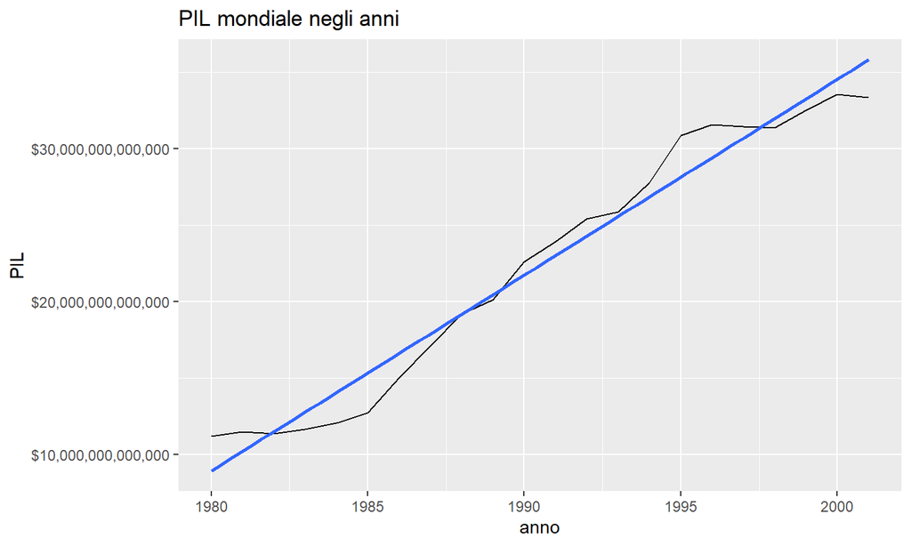

## Come sono cambiati gli incassi dei film nel corso degli anni?

- Possiamo notare, dal precedente grafico, una crescita lineare dagli anni ’80 ai primi anni 2000, con un lieve stallo in quest’ultimi.
- Dunque, è naturale chiedersi, se anche gli incassi dei film in questi anni abbia seguito questo trend.
- Ci affidiamo al seguente Plot.

## Secondo Plot

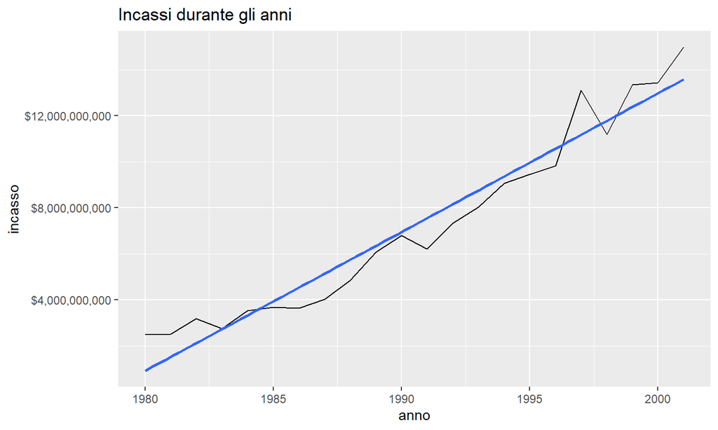

## Parte 2

- Come è cambiato il budget dei film negli anni?
- Dopo aver visto come sono cresciuti gli incassi nel tempo, andiamo a vedere come è cambiato il budget negli anni.
- Ci chiediamo quindi, se il budget a disposizione delle industria cinematografiche abbia accompagnato la crescita di tali incassi.
- Plottiamo ora il grafico, per avere risposta a tale indagine.

## Terzo Plot

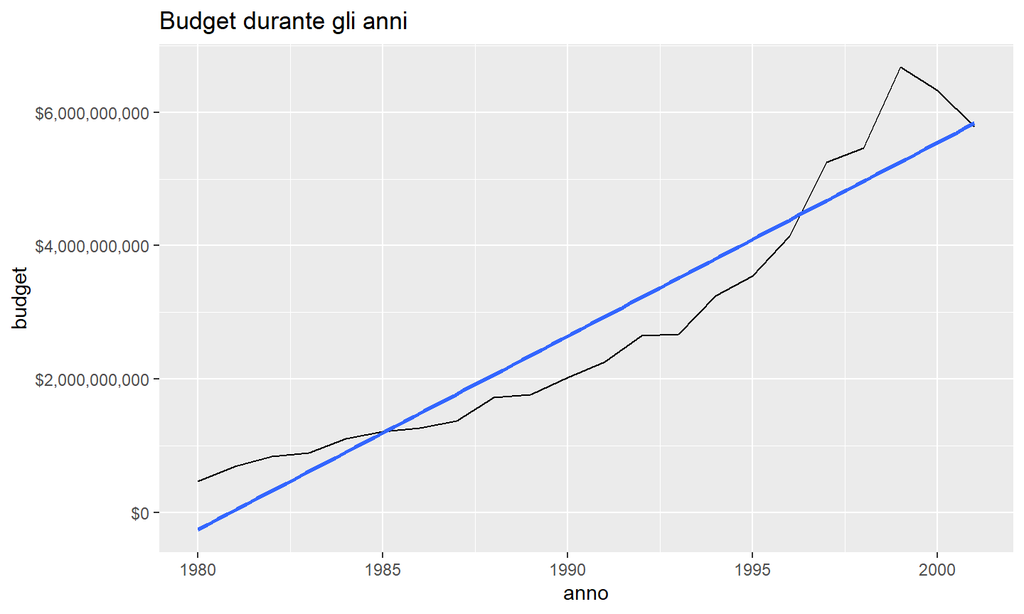

## Risultato

- Il budget è aumentato di conseguenza al crescere dell’industria cinematografica, con un picco associato all’arrivo del nuovo millennio e una lieve decrescita nei primi anni 2000.
- Ricordiamo che gli anni ’90 dell’industria cinematografica hanno prodotto dei capolavori come “Titanic”, “Star Wars” e “Jurassic Park”.
- Il budget associato a tali spettacoli era piuttosto elevato, per favorire effetti speciali e scene rivoluzionarie.

## Parte 3

- Ci chiediamo ora quali generi siano stati prodotti maggiormente nel periodo di interesse (1980-2001).
- Quali di questi generi hanno incassato maggiormente?
- Che risposta vi aspettereste a tali quesiti?

## Quali generi sono stati maggiormente prodotti?

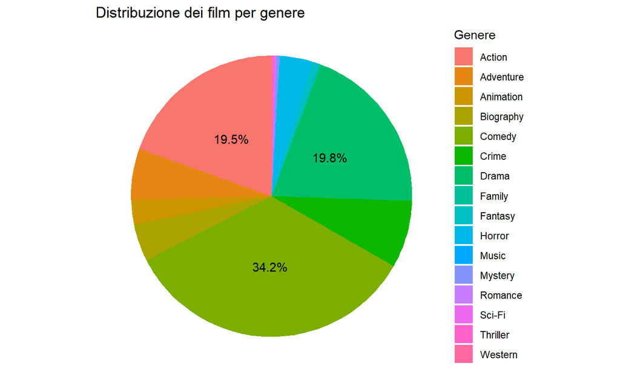

## Risultato del plot

- Possiamo notare come il genere “Comedy” occupi una percentaule maggiore rispetto agli altri.
- Altri generi prodotti in abbondanza, vengono collocati nei generi “Drama” e “Action”.
- I generi di nicchia occupano solo piccoli spicchi del grafico a torta.

## Quali generi hanno gli incassi maggiori?

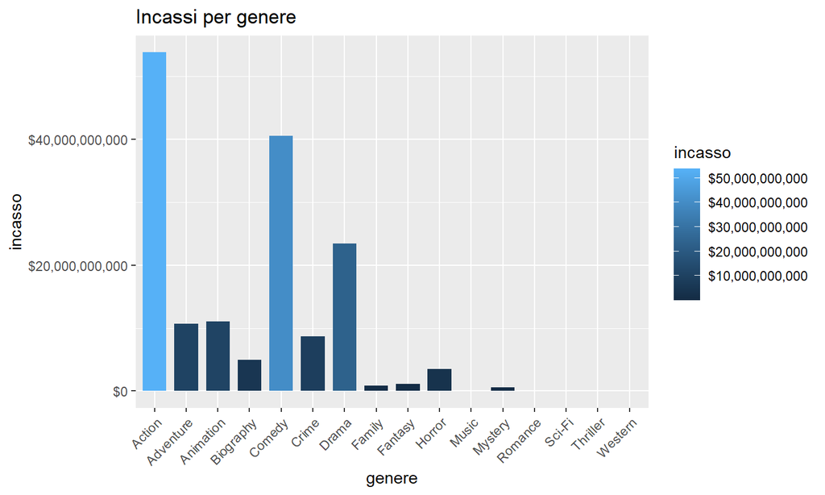

## Parlando di incassi

- Contrariamente al risultato precedente, possiamo notare come il genere “Action” abbia incassato molto di più rispetto agli altri generi, con oltre $50 miliardi di dollari.
- Sebbene il genere “Commedy” sia stato quello che conta più film prodotti, il suo incasso totale si classifica al secondo posto della graduatoria (40$ miliardi di dollari).
- Al terzo posto, troviamo il genere “Drama” che ha incassato oltre $20 miliardi.
- Altri generi, hanno incassato cifre relativamente basse rispetto alle categorie precedenti.

## Approfondimento

- Proponiamo un interessante approfondimento, ci chiediamo come sono cambiati gli incassi relativamente ai generi dei film nel corso del tempo.
- Come possiamo immaginare i generi maggiormente prodotti, variano negli anni. Gli interessi degli spettatori sono molto esigenti, e l’industria cinematografica ha dovuto portare dei cambiamenti.
- In particolare, esibiamo un grafico per mostrare la variazione degli incassi in 3 generi diversi (“Action”, “Comedy” e “Drama”).

## Plot approfondimento

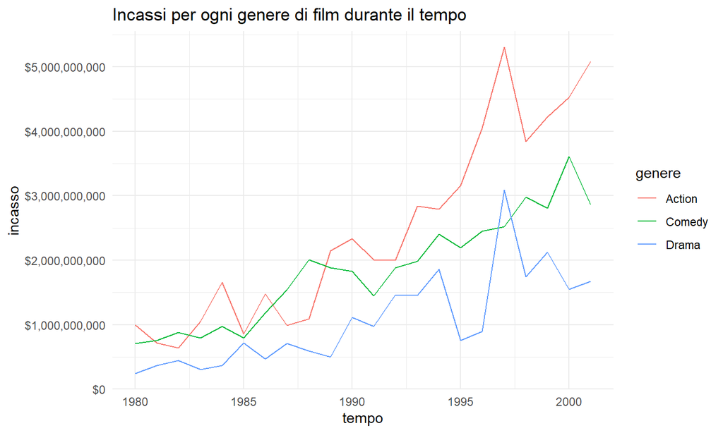

## Risultati approfondimento

- Possiamo vedere dalla precedente visualizzazione, come nel periodo compreso tra il 1995 e il 2000, ci siano stati dei picchi negli incassi, rispettivamente ai 3 generi proposti.
- Non è casuale, essendo che “Titanic”, film di grande successo per il genere “drama”, sia stato rilasciato nel 1997.
- Il 1997 è un periodo di notevole guadagno anche per il genere “action”, registrando oltre $5 miliardi di incassi.

## Ultima parte

- Come ultima indagine, proponiamo un grafico in cui mostriamo gli incassi nei film con Tom Cruise, relativamente ai generi in cui ha recitato.
- Tom Cruise, è un attore che ha suscitato in noi un particolare interesse essendo stato protagonista in film che tutti abbiamo amato come “Top Gun” e “Mission Impossible”.

## Ultimo Plot

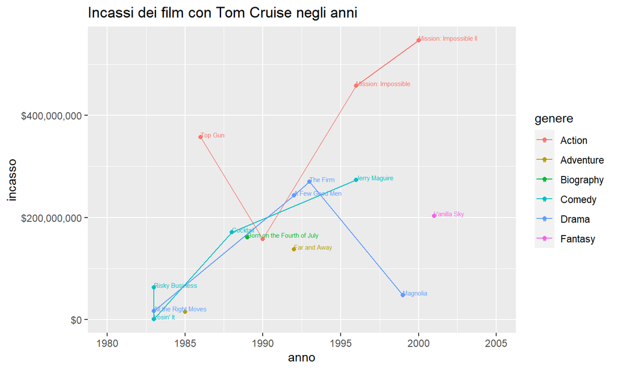

## In conclusione

- “Mission Impossible II” rappresenta il vertice di questo grafico, seguito da “Mission Impossible” e “Top Gun”, a livello di incassi.
- Il notevole talento di Tom, lo porta ad essere versatile in molti generi quali azione, dramma e commedia.
- Essendo questi generi quelli più richiesti dal pubblico, possiamo notare una correlazione con il suo successo.